# PANOPLY Tutorial

PANOPLY is a platform for applying state-of-the-art statistical and machine learning algorithms to transform multi-omic data from cancer samples into biologically meaningful and interpretable results. PANOPLY leverages [Terra](http://app.terra.bio)—a cloud-native platform for extreme-scale data analysis, sharing, and collaboration—to host proteogenomic workflows, and is designed to be flexible, automated, reproducible, scalable, and secure. A wide array of algorithms applicable to all cancer types have been implemented, and we highlight the application of PANOPLY to the analysis of cancer proteogenomic data.

This PANOPLY tutorial provides a tour of how to use the PANOPLY proteogenomic data analysis pipeline, using the breast cancer dataset published in Mertins, et. al.<sup>1</sup> The input dataset (`tutorial-brca-input.zip` file) can be found in the tutorial subdirectory, along with a HTML version of this tutorial.

## 1. Requirements

1. To run PANOPLY, you need a Terra account. To create an account follow the steps [here](https://support.terra.bio/hc/en-us/articles/360034677651-Account-setup-and-exploring-Terra). A Google account is required to create a Terra account.
2. Once you have an account, you need to create a [cloud billing account and project](https://support.terra.bio/hc/en-us/articles/360026182251-How-to-set-up-billing-in-Terra). Here, you will find step-by-step instructions to set up billing, including a free credits program for new users to try out Terra with $300 in Google Cloud credits.

## 2. Clone PANOPLY production workspace

Clone the Terra production workspace at PANOPLY_Production_Pipelines_v1_0.

1. Navigate to [workspace](https://app.terra.bio/#workspaces/broad-firecloud-cptac/PANOPLY_Production_Pipelines_v1_0). Click the circle with 3 dots at the top right and clone the workspace. When naming the new workspace, avoid special characters or spaces, and use *only* letters, numbers and underscores.

[figure not shown]

*Figure 1.* Cloning the production workspace

[figure not shown]

*Figure 2.* Naming the cloned workspace

## 3. Run PANOPLY startup notebook

Select the `NOTEBOOK` tab and click on `PANOPLY-startup-notebook`.

[figure not shown]

*Figure 3.* The `NOTEBOOK` tab with the `PANOPLY-startup-notebook`

The opened notebook is shown below:

[figure not shown]

*Figure 4.* Open PANOPLY startup notebook

Once the notebook is open, click on the `EDIT` button on top to start the Cloud Environment. The `Cloud Environment` popup will look like this:

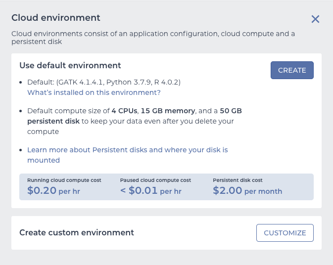

*Figure 5.* Cloud Environment Popup

Click on the `CUSTOMIZE` button, and choose `Custom Environment` in the `Application Configuration` pull-down menu. Enter `broadcptac/panda:1_0` in the `Container image` text box:

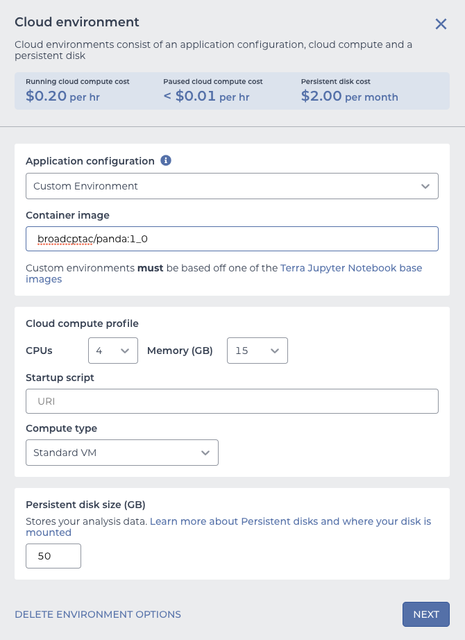

*Figure 6.* Cloud Environment with PANDA docker filled in

Then click `NEXT`. Click `CREATE` when the Unverified Docker image page shows up. Once the Cloud Environment is running and the notebook is in EDIT mode (this may take a few minutes), read and follow the instructions in the notebook. In the notebook

- Run the initialization code section by choosing `Cell -> Run Cells` or hitting `Shift-ENTER`.:

```
source( "/panda/build-config.r" )
panda_initialize("pipelines")
```

- The data has already been prepared and is available as a zip file [here](https://github.com/broadinstitute/PANOPLY/blob/dev/tutorial/tutorial-brca-input.zip). Download this file to your local computer and then upload it to the google bucket using instructions in the `Upload ZIP file to workspace bucket` section of the notebook.
- Run

```
panda_datatypes()
```

to list numerical mapping of allowable input data types. Then run

```
panda_input()
```

provide the to uploaded input `zip` file as input and map files with datatypes as shown below:

```
$$ Enter uploaded zip file name (test.zip): tutorial-brca-input.zip
.. brca-retrospective-v5.0-cna-data.gct: 6
.. brca-retrospective-v5.0-phosphoproteome-ratio-norm-NArm.gct: 2
.. brca-retrospective-v5.0-proteome-ratio-norm-NArm.gct: 1
.. brca-retrospective-v5.0-rnaseq-data.gct: 5
.. brca-retrospective-v5.0-groups.csv: 8
.. brca-retrospective-v5.0-sample-annotation.csv: 7
.. master-parameters_tutorial.yaml: 9
.. msigdb_v7.0_h.all.v7.0.symbols.gmt: 11
Does proteomics data need normalization? (y/n): n

============================
.. INFO. Sample annotation file successfully validated.
============================
.. INFO. Validating sample IDs in other files ..
.. INFO. cna successfully validated.
.. INFO. phosphoproteome successfully validated.
.. INFO. proteome successfully validated.
.. INFO. rna successfully validated.
============================
.. DONE.
============================
```

- Provide `groups` for annotation, association and enrichment analysis. A `groups` file is already included in the input to choose specific annotations for this purpose. Retain the groups file:

```
max.categories <- 10
panda_groups()
```

```
Groups file already present. Keep it? (y/n): y
.. Selected groups:
 1: PAM50
 2: ER.Status
 3: PR.Status
 4: HER2.Status
 5: TP53.mutation
 6: PIK3CA.mutation
 7: GATA3.mutation
============================
.. DONE.
============================
```

- Skip down to the **Sample Sets** section and run

```
panda_sample_subsets()
```

and do no add any additional sample subsets:

```
$$ Add additional sample subsets? (y/n): n
============================
.. Sample sets to be added to Terra Workspace:
.. all
============================
.. DONE.
============================
```

By default a sample set with all the input samples will be created.

- Finalize options:

```
panda_finalize()
```

```
============================
.. DONE.
============================
```

and run PANDA:

```
run_panda()
```

[figure not shown]

*Figure 7.* Data Tab in the workspace

and several directories with data files will be created on the google bucket (accessed via the `Files` button on the left side in the `DATA` tab).

[figure not shown]

*Figure 8.* Files in google bucket associated with workspace

## 4. Run Workflow

Once the startup notebook has completed running, and the data tables and files have been populated, navigate to the `WORKFLOWS` tab, locate the `panoply_main_proteome` workflow and click on it. A screen like the image below will appear:

[figure not shown]

*Figure 9.* The `panoply_main` workflow screen for setting inputs and running the workflow

Fill out the `job_identifier` with an appropriate name. All other required (and some optional) inputs will be already correctly configured to use data tables created by running the startup notebook. Further, in the top section, ensure that:

- The `Run workflow(s) with inputs defined by data table` radio button is selected
- Under `Step 1`, the root entity type is set to `sample_set`

Click `SELECT DATA` under `Step 2` and select the `all` sample_set:

[figure not shown]

*Figure 10.* Choosing data to run the `panoply_main` workflow on

Click `OK` on the `Select Data` screen to return to the `panoply_main_proteome` workflow. Click `SAVE` to save your choices, at which point the `RUN ANALYSIS` button will be enabled. Note that all the required and optional input for the workflow are automatically filled in, and linked to appropriate data files in the Google bucket via columns in the data table.

Start the workflow by clicking the `RUN ANALYSIS` button, and confirm launch by clicking the `LAUNCH` button on the popup:

[figure not shown]

*Figure 11.* The `Confirm Launch` popup

The progress of the launched job can be monitored using the `JOB HISTORY` tab:

[figure not shown]

*Figure 12.* The `JOB HISTORY` tab

## 5. Inspect and download results

On successful completion of the submitted job, the `JOB HISTORY` tab will show a `Succeeded` status for the job.

[figure not shown]

*Figure 13.* The `JOB HISTORY` tab after successful job completion.

Click on `View` (circled in red in the Figure) to get to the `Job Manager` page. Here, select the `OUTPUTS` tab to see all output files:

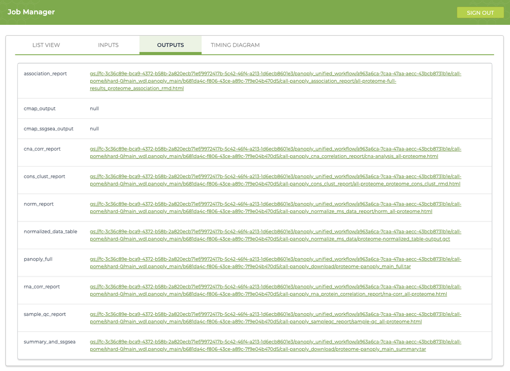

*Figure 14.* The `Job Manager` page.

## Results and output reports

Running PANOPLY workflows generate several interactive `*_report`s that are HTML files with a summary of results from the appropriate analysis modules. In addition, all the reports with single-sample GSEA output is contained in the `summary_and_ssgsea` section. The complete output including all output tables, figures and results can be found in the file pointed to by `panoply_full`. All output files reside on the Google bucket associated with the execution workspace, and can be accessed by clicking on the links in the `OUTPUTS` page. Many files can be viewed directly by following the links, and all files can be downloaded either through the browser, or using the `gsutil cp` command in a terminal window. Detailed descriptions of the reports and results can be found at [Navigating Results](https://github.com/broadinstitute/PANOPLY/wiki/Navigating-Results).

## Time and Cost

The table below summarizes expected time and cost for running various components of PANOPLY on the tutorial dataset. The table also provides ballpark estimates and ranges for each component assuming default parameter settings.

The time and cost can vary depending on runtime conditions, pre-emption of running jobs, and parameter settings. For example, increasing the number of random permutations for multi-omics NMF clusters (`panoply_mo_nmf`) or CMAP analysis (`panoply_cmap_analysis`) will result in proportional increase in cost and time. Terra also includes a caching mechanism that reuses results for modules with no changes (to the module and input data/parameters). Enabling call caching can result in significant cost and time savings when only a few modules in a pipeline need to be rerun. In addition, Terra dispatches modules in parallel – modules with input data available are run in parallel. This reduces total pipeline run time when compared to the cumulative time needed to run all modules.

| Item |  | Approx. Time (Range) | Approx. Cost (Range) |
| --- | --- | --- | --- |
| Startup Notebook to prepare workspace (`panda`) |  | 45 min (30-60 min) | $1 ($0-$1) |
| Main pipeline for proteome data (`panoply_main`) |  | 3.5 hr (3-4 hr) | $2 ($1-$5) |
| Unified pipeline for proteome+PTM, including NMF multi-omics clustering and CMAP analysis (`panoply_unified_workflow`) |  |  |  |
|  | Total | 9.5 hr (8-10 hr) | $55 ($50-$75) |
|  | Main pipeline on proteome+PTM (`panoply_main`) | 4.5 hr (3-5 hr) | $5 ($1-$10) |
|  | Multi-omics NMF clustering (`panoply_mo_nmf`) | 4 hr (3-4 hr) | $25 ($15-$50) |
|  | CMAP analysis (`panoply_cmap_analysis`) | 3 hr (2-3 hr) | $25 ($15-$50) |
| Storage for input data + results of pipeline runs (~15 GB total) |  |  | $2-$3 / month |

### References

1. Mertins, P. et al. Proteogenomics connects somatic mutations to signalling in breast cancer. Nature 534, 55–62 (2016).